# Convolutional Neural Networks

# Project: Write an Algorithm for a Dog Identification App

### Why We're Here

As part of Udacity online course on Deep Learning, this notebook is my first 'hands-on' exercise to use convolutionnal neural networks to classify images.

I'm tackling the very classic problem of dog classification. The goal is to build a model capable of doing breed classification of a dog by just “looking” into its image.

If a dog is detected in the image, the app should provide an estimate of the dog's breed. If it's a human, it will provide an estimate of the dog breed that is most resembling.

[figure not shown]

In this real-world setting, I needed to piece together a series of models to perform different tasks; for instance, the algorithm that detects humans in an image will be different from the CNN that infers dog breed.

### Log Book

Let's describe this journey.

I learned that the practice is far ahead of the theory in deep learning :)

First, I tried to build a CNN from scratch. This model had to learn how to see by seeing only *a few* dog images. I experimented with many (many!!) different architectures... My main trouble was **OVERFITTING**. Indeed, with only 64 sample images from 133 classes, my from scratch model had difficulties to generalize. I took me hours of litterature reading, to handle overfitting, nights of training to test hyperparameters, almost drove me crazy not to do better than 35%! I conclueded, that **one cannot properly learn how to see if it only sees dogs**!

Then, using transfer learning, I could take advantage of a model already *sees*, ie. recognizes patterns, textures, colors... and I *only* neeeded to teach him how to recognize dog breeds. With the very same sets preparation, it took me about half an hour to choose and implement the model, trained it for only 5 epochs and get >80% accuaracy.

#### Standing on the shoulders of giants

There are a lot of very inspiring works already done, that I could read and take inspirations from, to quote a few: **Medium paper tackling the very same exercise**

- https://towardsdatascience.com/dog-breed-classification-hands-on-approach-b5e4f88c333e
- https://medium.com/@imBharatMishra/dog-breed-classification-with-keras-848b9b1525c1
- https://medium.com/@iliazaitsev/dogs-breeds-classification-with-keras-b1fd0ab5e49c
- https://towardsdatascience.com/dog-breed-prediction-using-cnns-and-transfer-learning-22d8ed0b16c5

**Very instructive course on fast AI**

- https://course.fast.ai/videos/?lesson=6

**On optimization: gradient descent optimizer and batch normalization**

- https://towardsdatascience.com/adam-latest-trends-in-deep-learning-optimization-6be9a291375c
- https://ruder.io/optimizing-gradient-descent/index.html#whichoptimizertochoose
- https://towardsdatascience.com/batch-normalization-in-neural-networks-1ac91516821c

**One Shot Learning with Siamese Networks** I did not really work for me as good as I expected but I took time to do a 'POC' using Siamese network to teach a network to estimate the dissimilarity between two dog pictures. I certainly neeed to refine my architecture, but I took so long to train and test that I did not pursued in that direction... I'll put the exploratory notebook in this repository though.

- https://www.google.com/search?q=siamese+network&oq=Siamesee&aqs=chrome.1.69i57j0l5.2017j0j4&sourceid=chrome&ie=UTF-8

#### Take away

If I were to build a model from scratch, I'll certainly be carefull on the followings, that helped me fight against overfitting:

- **Dropout:** remove activations at random during training in order to regularize the model
- **Data augmentation:** modify model inputs during training in order to effectively increase data size
- **Batch normalization** : adjust the parameterization of a model in order to make the loss surface smoother
- **Residual**: As explained in fast.ai course, this trick has been discovered by chance and improved my performances, as it did it the imagenet dataset (https://arxiv.org/pdf/1512.03385.pdf)
- **Optimizer & Batch size**: I first added a momentum on my SGD optimizer, to accelerate the training, but I had trouble to adjust together (batch size, learning rate, momentum). I then readed about Adam Optimizer that is adaptative, which indeed was easyer to use. Also, I started with batch size of 64, but the variability on losses across epochs was large, as if the model learned too much before validation check, so I decreased batch size to 20. Something that would worse testing that would be instead of Adam, try Optimgrad or SGD with nesterov momentum (need to choose parameters).

### The Road Ahead

We break the notebook into separate steps.

- Step 0: Import Datasets
- Step 1: Detect Humans
- Step 2: Detect Dogs
- Step 3: Create a CNN to Classify Dog Breeds (from Scratch)
- Step 4: Create a CNN to Classify Dog Breeds (using Transfer Learning)
- Step 5: Write your Algorithm
- Step 6: Test Your Algorithm
- Step 7: Compare scratch and transfer results

# Let's get our feet wet!

## Step 0: Import Datasets

Make sure that you've downloaded the required human and dog datasets:

- Download the [dog dataset](https://s3-us-west-1.amazonaws.com/udacity-aind/dog-project/dogImages.zip). Unzip the folder and place it in this project's home directory, at the location `/dog_images`.
- Download the [human dataset](https://s3-us-west-1.amazonaws.com/udacity-aind/dog-project/lfw.zip). Unzip the folder and place it in the home directory, at location `/lfw`.

*Note: If you are using a Windows machine, you are encouraged to use [7zip](http://www.7-zip.org/) to extract the folder.*

In the code cell below, we save the file paths for both the human (LFW) dataset and dog dataset in the numpy arrays `human_files` and `dog_files`.

```python
import matplotlib as mpl
mpl.rcParams['axes.grid'] = False
mpl.rcParams['image.interpolation'] = 'nearest'
mpl.rcParams['figure.figsize'] = 15, 25

def show_dataset(dataset, n_edition=6, n_image=3, title=''):
    plt.figure()
    idx = np.arange(len(dataset))
    np.random.shuffle(idx)
    img = np.vstack((np.hstack((np.asarray(dataset[idx[i]][0]) for _ in range(n_edition)))
                   for i in range(n_image)))
    plt.imshow(img)
    plt.axis('off')
    plt.title(title, fontsize=30)
```

```python
def show_image(img, title=None, ax=None, resize=None):
    if isinstance(img, str):
        img = cv2.imread(img)
    elif not isinstance(img, np.ndarray):
        raise ValueError('img should be of a path or an array. ')
    if resize is not None:
        img = cv2.resize(img, resize)
    cv_rgb = cv2.cvtColor(img, cv2.COLOR_BGR2RGB)
    plt.imshow(cv_rgb)
    if title is not None:
        plt.title(title)
```

```python
import numpy as np
from glob import glob

# load filenames for human and dog images
human_files = np.array(glob("./data/lfw/*/*"))
dog_files = np.array(glob("./data/dog_images/*/*/*"))

# print number of images in each dataset
print('There are %d total human images.' % len(human_files))
print('There are %d total dog images.' % len(dog_files))
```

```
There are 13233 total human images.
There are 8351 total dog images.
```

```python
 class ConfigPath():
    dogs = './data/dog_images'
    humans = './data/human_images'
```

## Step 1: Detect Humans

In this section, we use OpenCV's implementation of [Haar feature-based cascade classifiers](http://docs.opencv.org/trunk/d7/d8b/tutorial_py_face_detection.html) to detect human faces in images.

OpenCV provides many pre-trained face detectors, stored as XML files on [github](https://github.com/opencv/opencv/tree/master/data/haarcascades). We have downloaded one of these detectors and stored it in the `haarcascades` directory. In the next code cell, we demonstrate how to use this detector to find human faces in a sample image.

```
Number of faces detected: 1
```

[figure not shown]

```python
import cv2
import matplotlib.pyplot as plt
%matplotlib inline

# extract pre-trained face detector
face_cascade = cv2.CascadeClassifier('haarcascades/haarcascade_frontalface_alt.xml')

# load color (BGR) image
img = cv2.imread(human_files[15])
# convert BGR image to grayscale
gray = cv2.cvtColor(img, cv2.COLOR_BGR2GRAY)

# find faces in image by executing
# the classifier stored in `face_cascade`, that
# takes the grayscale image as a parameter.
faces = face_cascade.detectMultiScale(gray)

# print number of faces detected in the image
print('Number of faces detected:', len(faces))

# get bounding box for each detected face
for (x,y,w,h) in faces:
    # add bounding box to color image
    cv2.rectangle(img,(x,y),(x+w,y+h),(255,0,0),2)

# convert BGR image to RGB for plotting
cv_rgb = cv2.cvtColor(img, cv2.COLOR_BGR2RGB)

# display the image, along with bounding box
plt.imshow(cv_rgb)
plt.show()
```

Before using any of the face detectors, it is standard procedure to convert the images to grayscale. The `detectMultiScale` function executes the classifier stored in `face_cascade` and takes the grayscale image as a parameter.

In the above code, `faces` is a numpy array of detected faces, where each row corresponds to a detected face. Each detected face is a 1D array with four entries that specifies the bounding box of the detected face. The first two entries in the array (extracted in the above code as `x` and `y`) specify the horizontal and vertical positions of the top left corner of the bounding box. The last two entries in the array (extracted here as `w` and `h`) specify the width and height of the box.

### Write a Human Face Detector

We use this procedure to write a function that returns `True` if a human face is detected in an image and `False` otherwise.

```python
def face_detector(img_path):
    """Returns "True" if face is detected in image stored at img_path
        Args:
            img_path (str):  file path to an image
        Returns:
            Bool: `True` if a human face is detected in an image and `False` otherwise.
    """
    img = cv2.imread(img_path)
    gray = cv2.cvtColor(img, cv2.COLOR_BGR2GRAY)
    faces = face_cascade.detectMultiScale(gray)
    return len(faces) > 0
```

### Assess the Human Face Detector

**Question 1:** Test the performance of the `face_detector` function.

- What percentage of the first 100 images in `human_files` have a detected human face?
- What percentage of the first 100 images in `dog_files` have a detected human face?

Ideally, we would like 100% of human images with a detected face and 0% of dog images with a detected face. You will see that our algorithm falls short of this goal, but still gives acceptable performance. We extract the file paths for the first 100 images from each of the datasets and store them in the numpy arrays `human_files_short` and `dog_files_short`.

**Answer:** (You can print out your results and/or write your percentages in this cell)

```python
human_files_short = human_files[:100]
dog_files_short = dog_files[:100]

# Test the performance of the face_detector algorithm
# on the images in human_files_short and dog_files_short.
human_detector_accuracy = np.mean(list(map(face_detector, list(human_files_short))))*100
dog_detector_accuracy = np.mean(list(map(face_detector, list(dog_files_short))))*100
print('Human face detected in human pictures is of %d percent.' % human_detector_accuracy)
print('Human face detected in dog pictures is of %d percent.' % dog_detector_accuracy)
```

```
Human face detected in human pictures is of 99 percent.
Human face detected in dog pictures is of 18 percent.
```

## Step 2: Detect Dogs

In this section, we use a [pre-trained model](http://pytorch.org/docs/master/torchvision/models.html) to detect dogs in images.

### Obtain Pre-trained VGG-16 Model

The code cell below downloads the VGG-16 model, along with weights that have been trained on [ImageNet](http://www.image-net.org/), a very large, very popular dataset used for image classification and other vision tasks. ImageNet contains over 10 million URLs, each linking to an image containing an object from one of [1000 categories](https://gist.github.com/yrevar/942d3a0ac09ec9e5eb3a).

```python
import torch
import torchvision.models as models

# define VGG16 model
VGG16 = models.vgg16(pretrained=True)

# check if CUDA is available
use_cuda = torch.cuda.is_available()

# move model to GPU if CUDA is available
if use_cuda:
    VGG16 = VGG16.cuda()
```

Given an image, this pre-trained VGG-16 model returns a prediction (derived from the 1000 possible categories in ImageNet) for the object that is contained in the image.

### Making Predictions with a Pre-trained Model

In the next code cell, we will write a function that accepts a path to an image (such as `'dogImages/train/001.Affenpinscher/Affenpinscher_00001.jpg'`) as input and returns the index corresponding to the ImageNet class that is predicted by the pre-trained VGG-16 model.

We go read how to appropriately pre-process tensors for this pre-trained VGG models in the [PyTorch documentation](http://pytorch.org/docs/stable/torchvision/models.html). It's said:

> *During training, the input to our ConvNets is a fixed-size 224 × 224 RGB image. The only preprocessing we do is subtracting the mean RGB value, computed on the training set, from each pixel.*

We download class labels used when training VGG as json have been downloaded from: `https://s3.amazonaws.com/outcome-blog/imagenet/labels.json` and saved it in `./data/imagenet_labels.json`.

```python
from PIL import Image
import requests
import io
import json
from torch.autograd import Variable
import torchvision.models as models
import torchvision.transforms as transforms
import torch.nn as nn

vgg16_transforms = transforms.Compose([transforms.Resize((224, 224)),
                                             transforms.ToTensor(),
                                             transforms.Normalize(mean=[0.485, 0.456, 0.406],
                                                                  std=[0.229, 0.224, 0.225])])

with open('data/imagenet_labels.json') as json_data:
    labels = json.load(json_data)
imagenet_labels = {int(key): value for key, value in labels.items()}

def VGG16_predict(img_path, verbose=False):
    '''
    Use pre-trained VGG-16 model to obtain index corresponding to
    predicted ImageNet class for image at specified path

    Args:
        img_path (str): path to an image
        verbose (bool): if True, print out results.
    Returns:
        Index corresponding to VGG-16 model's prediction
    '''

    # Load the image from the given img_path
    img = Image.open(img_path)  # Read bytes and store as an img.
    # Pre-process the image and convert it to a tensor
    img = vgg16_transforms(img)
    # Unsqueeze inserts a new axis, to convert format (num color channels, height, width) to (num input imgs, num color channels, height, width).
    img = img.unsqueeze(0)  # Insert the new axis at index 0 i.e. in front of the other axes/dims.
    # Pytorch pretrained model expects Variable as inputs
    img = Variable(img)
    # Get probability from VGG output
    m = nn.Softmax()
    prediction = m(VGG16(img))  # Returns a Tensor of shape (batch, num class labels)
    precision = prediction.data.numpy().max()*100  # Our precision is defined as softmax probability x 100
    max_prediction = prediction.data.numpy().argmax()  # Our prediction will be the index of the class label with the largest value.
    if verbose:
        label = imagenet_labels[max_prediction]
        print(f'VGG predicted {label} with precision %.2f%% percent' %precision)  # Converts the index to a string using our labels dict
        show_image(img_path, title=label)
    # Return the *index* of the predicted class for that image
    return max_prediction # predicted class index
```

```
VGG predicted French bulldog with precision 99.18% percent
```

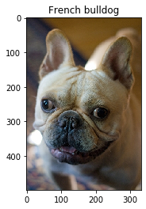

```python
_ = VGG16_predict(dog_files[4], verbose=True)
```

### Write a Dog Detector

While looking at the [dictionary](https://gist.github.com/yrevar/942d3a0ac09ec9e5eb3a), we notice that the categories corresponding to dogs appear in an uninterrupted sequence and correspond to dictionary keys 151-268, inclusive, to include all categories from `'Chihuahua'` to `'Mexican hairless'`. Thus, in order to check to see if an image is predicted to contain a dog by the pre-trained VGG-16 model, we need only check if the pre-trained model predicts an index between 151 and 268 (inclusive).

Use these ideas to complete the `dog_detector` function below, which returns `True` if a dog is detected in an image (and `False` if not).

```python
dog_index = np.arange(151,269)
def dog_detector(img_path, verbose=False):
    """Returns "True" if a dog is detected in an image stored at img_path
        Args:
            img_path (str):  file path to an image
        Returns:
            Bool: `True` if a dog is detected in an image and `False` otherwise.
    """
    predict_index = VGG16_predict(img_path, verbose)  # Our prediction will be the index of the class label with the largest value.
    return predict_index in dog_index
```

### Assess the Dog Detector

**Question 2:** Let us test the performance of our `dog_detector` function.

And now, I'm asking myself a crucial question: 🤔

🐶👨*Is it human present on dog's image, like walking their dogs, or... dog looking like human?* 🐶👨

```python
from functools import partial
from tqdm import tqdm

dog_percentage = np.mean(list(map(partial(dog_detector, verbose=False), tqdm(list(dog_files_short)))))*100
human_percentage = np.mean(list(map(partial(dog_detector, verbose=False), tqdm(list(human_files_short)))))*100

print('Dog detection performance: %.2f%%' %dog_percentage)
print('Human present on dog images (or dog looking like human?) : %.2f%%' %human_percentage)
```

```
Dog detection performance: 98.00%
Human present on dog images (or dog looking like human?) : 0.00%
```

We suggest VGG-16 as a potential network to detect dog images in your algorithm, but you are free to explore other pre-trained networks (such as [Inception-v3](http://pytorch.org/docs/master/torchvision/models.html#inception-v3), [ResNet-50](http://pytorch.org/docs/master/torchvision/models.html#id3), etc). Please use the code cell below to test other pre-trained PyTorch models. If you decide to pursue this *optional* task, report performance on `human_files_short` and `dog_files_short`.

```python
### (Optional)
### TODO: Report the performance of another pre-trained network.
### Feel free to use as many code cells as needed.
```

## Step 3: Create a CNN to Classify Dog Breeds (from Scratch)

Now that we have functions for detecting humans and dogs in images, we need a way to predict breed from images. In this step, we will create a CNN that classifies dog breeds.

We must create our CNN *from scratch* (so, we can't use transfer learning *yet*!), and we must attain a test accuracy of at least 10%. In Step 4 of this notebook, you will have the opportunity to use transfer learning to create a CNN that attains greatly improved accuracy.

We mention that the task of assigning breed to dogs from images is considered exceptionally challenging. To see why, consider that *even a human* would have trouble distinguishing between a Brittany and a Welsh Springer Spaniel.

| Brittany | Welsh Springer Spaniel |
| --- | --- |

It is not difficult to find other dog breed pairs with minimal inter-class variation (for instance, Curly-Coated Retrievers and American Water Spaniels).

We also mention that random chance presents an exceptionally low bar: setting aside the fact that the classes are slightly imabalanced, a random guess will provide a correct answer roughly 1 in 133 times, which corresponds to an accuracy of less than 1%.

### Data and transformation exploration

I am interested in augmenting my training data, but not my validating and testing data.  
Hence, I checked out the wide variety of [transforms](http://pytorch.org/docs/stable/torchvision/transforms.html?highlight=transform) and visualize their effect on my dogs. The purpose here is to augment the training data with plausible transformation only. Indeed, we don't want the model to learn on vertical-flipped image or on green-looking dogs.

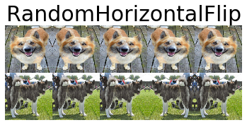

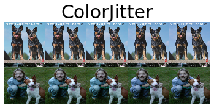

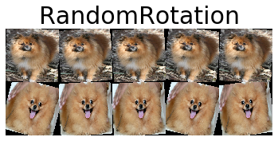

```python
# Let us try out some transformations
import os
from torchvision import datasets, transforms
test_transforms = dict(RandomHorizontalFlip=transforms.RandomHorizontalFlip(),
                      ColorJitter=transforms.ColorJitter(hue=.02, saturation=.02),
                      RandomRotation =transforms.RandomRotation((-15,15))
                      )
for transform_name, transform in test_transforms.items():
    test_transform = transforms.Compose([
    transforms.Resize((224,224)),
    transform,
    ])
    dataset = datasets.ImageFolder(f'{ConfigPath.dogs}/train/', transform=test_transform)
    show_dataset(dataset, n_edition=5, n_image=2, title=transform_name)
```

```python
import pandas as pd
import seaborn as sns
from imageio import imread
```

```
83% of the image are larger than :
 width     232.452924
height    209.311127
dtype: float64
```

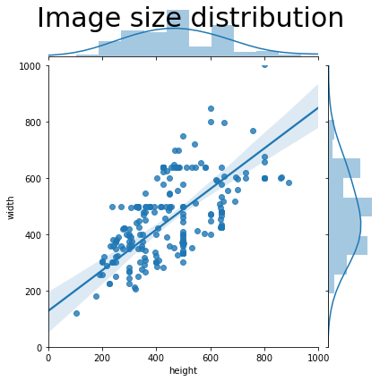

```python
dog_image_shapes = np.asarray([imread(dog_file).shape for dog_file in dog_files[:300]])
dog_image_shapes = pd.DataFrame(dog_image_shapes[:, :2], columns=['width', 'height'])
sns.jointplot(data=dog_image_shapes, x='height', y='width', kind='reg',
              xlim=(0, 1000), ylim=(0, 1000))
plt.suptitle('Image size distribution', fontsize=30)
print(f'83% of the image are larger than : \n {dog_image_shapes.mean() - 1*dog_image_shapes.std()}')
```

**Question 3:** Describe your chosen procedure for preprocessing the data.

- How does my code resize and prepare the images?
- Did you decide to augment the dataset? If so, how (through translations, flips, rotations, etc)? If not, why not?

**Answer**:

### Data Loaders for the Dog Dataset

```python
# check if CUDA is available
use_cuda = torch.cuda.is_available()
device = torch.device("cuda:0" if use_cuda else "cpu")

resize = [
          # Resize the input PIL Image to the given size.
          transforms.Resize(224),
          # Crops the given PIL Image at the center.
          transforms.CenterCrop(224)]

to_tensor = [
              # Convert imagee to tensor
              transforms.ToTensor(),
              # Normalize the tensor image with mean and standard deviation
              # Here, mean and std are taken from imagenet database, so we
              # kind of 'zscore' our data in R, G, B dimensions.
              transforms.Normalize(mean=[0.485, 0.456, 0.406],
                                   std=[0.229, 0.224, 0.225])]

image_augmentation = [
                      transforms.ColorJitter(hue=.1, saturation=.1),
                      transforms.RandomRotation((-40,40)),
                      transforms.RandomHorizontalFlip()]

scratch_transforms = {
    'train': transforms.Compose(resize + image_augmentation + to_tensor) ,
    'valid': transforms.Compose(resize + to_tensor) ,
    'test': transforms.Compose(resize + to_tensor)
             }

image_folders = {folder: datasets.ImageFolder(f'{ConfigPath.dogs}/{folder}/',
                          transform=scratch_transforms[folder])
                 for folder in ['train', 'valid', 'test']}

def get_loaders(batch_size, **kwargs):
    return {folder: torch.utils.data.DataLoader(image_folders[folder],
                                                       # shuffle only train data
                                                       shuffle=folder=='train',
                                                        batch_size=batch_size,
                                                       **kwargs)
                 for folder in ['train', 'valid', 'test']}
loaders_scratch = get_loaders(batch_size=20, num_workers=0)
```

```python
dog_breeds = image_folders['train'].classes
N = len(dog_breeds)
print(f'The network should have {N} outputs. ')
```

```
The network should have 133 outputs.
```

### Model Architecture

**Define helpers to avoid repeting always the same lines of code when defining the network.**

In the cell bellow, I buid helpers to design a convolutionnal layer. Based on the litterature I read, and advices from experienced people, I tested different type of layers, from the simplest to the complex:

- basic: (Conv2d, ReLu activation)
- with batch norm: (Conv2d, Batch norm 2d, ReLu activation)
- with batch norm and residual (using short-cuts to jump over some layers): (Conv2d, ResBlock with batch norm, ReLu activation)

Each convolution has the following parameters:

- ni: nb of inputs
- nf: nb of outputs
- downsampling_method: stride or maxpool
- kernel_size: size of filter

```python
import torch.nn as nn
def Conv2d(ni,nf, downsampling_method='stride', downsampling_factor=2, kernel_size=3):
    if downsampling_method == 'stride':
        return nn.Conv2d(ni, nf, kernel_size=kernel_size, stride=downsampling_factor, padding=1)
    elif  downsampling_method == 'maxpool':
        return nn.Sequential(Conv2d(ni, nf, kernel_size=kernel_size, stride=1, padding=1),
                             nn.MaxPool2d(downsampling_factor, downsampling_factor))
    else: # downsampling_method == 'avgpool'
        return nn.Sequential(Conv2d(ni, nf, kernel_size=3, stride=1, padding=1),
                             nn.AvgPool2d(downsampling_factor, downsampling_factor))

# basic convolutional layer (no normalization)
def ConvLayer_basic(ni, nf, downsampling_method='stride', downsampling_factor=2, kernel_size=3):
    return nn.Sequential(Conv2d(ni, nf, downsampling_method, downsampling_factor, kernel_size=kernel_size),
                         nn.ReLU())

# convolutional layer with batch normalization 2d
def ConvLayer_bnorm(ni,nf, downsampling_method='stride', downsampling_factor=2, kernel_size=3):
    return nn.Sequential(
           Conv2d(ni, nf, downsampling_method, downsampling_factor, kernel_size=kernel_size),
           nn.BatchNorm2d(nf),
           nn.ReLU())

def LinearLayer_basic(in_features, out_features):
    return nn.Sequential(nn.Linear(in_features, out_features),
                      nn.ReLU())

def LinearLayer_bnorm(in_features, out_features):
    return nn.Sequential(nn.Linear(in_features, out_features),
                      nn.BatchNorm1d(out_features),
                      nn.ReLU())

# convolutional layer with batch normalization 2d and Resnet-ish
class ResBlock(nn.Module):
    def __init__(self, nf):
        super().__init__()
        self.conv1 = ConvLayer_bnorm(nf,nf, downsampling_factor=1)
        self.conv2 = ConvLayer_bnorm(nf,nf, downsampling_factor=1)

    def forward(self, x):
        return x + self.conv2(self.conv1(x))

def ConvLayer_residual(ni,nf, downsampling_method='stride', downsampling_factor=2, kernel_size=3):
    return  nn.Sequential(Conv2d(ni, nf, downsampling_method, downsampling_factor, kernel_size),
            ResBlock(nf),
            nn.ReLU())
```

**Create a CNN to classify dog breeds.** Here, I create the network and keep the important architecture parameters in an object (this allows me to test many different architecture, just by changing this cell)

Here, the network has 6 CNN layers (to build feature maps):

```
* FEATURES LAYERS: (input_depth, 16) (16,32) (32, 64) (64, 64) (64, 256) (256, 512)
```

We choose a dropout probability of 0.25 that applies after each layer.

The classifier has 2 fully connected layers:

```
* CLASSIF. LAYERS: 4*4*512 -> 1330 -> 133
```

The training params are:

[output not shown]

Each convolutional layer is of type RESIDUAL.

```python
import torch.optim as optim
class ConfigScratchModel():
    NAME = 'model_scratch_CNN-Residual-6-CEL_Adam-1e-4'
    NET = dict(
        n_hidden_features_filters = [16, 32, 64, 64, 256, 512],
        n_hidden_features_kernel = [5, 3, 3, 3, 3, 3],
        n_inputs_classifier = int(4*4*512)   ,
        n_hidden_classifier=1330,
        n_outputs_classifier=133,
        conv='residual',
        downsampling_factor=2,
        downsampling_method='stride',
        p_dropout=0.25)
    LEARNING_RATE = 0.00001
    CRITERION = nn.CrossEntropyLoss
    OPTIMIZER = partial(optim.Adam, lr=LEARNING_RATE)
    BATCH_SIZE = 20
```

```python
import torch.nn.functional as F
# set PIL to tolerate truncated images:
from PIL import ImageFile
ImageFile.LOAD_TRUNCATED_IMAGES = True

# define the CNN architecture
class Net(nn.Module):
    def __init__(self, input_size=[224, 224, 3],
                 n_hidden_features_filters = [16, 32, 64, 64, 256, 512],
                 n_hidden_features_kernel = [5, 3, 3, 3, 3, 3],
                 n_inputs_classifier = int(4*4*512),
                 n_hidden_classifier=1330,
                 n_outputs_classifier=133,
                 conv='basic',
                 downsampling_factor=2,
                 downsampling_method='stride',
                 p_dropout=0.25):
        if conv == 'basic':
            conv_layer = ConvLayer_basic
            linear_layer = LinearLayer_basic
        elif conv == 'bnorm':
            conv_layer = ConvLayer_bnorm
            linear_layer = LinearLayer_bnorm
        else: # conv == 'residual'
            conv_layer = ConvLayer_residual
            linear_layer = LinearLayer_bnorm
        super(Net, self).__init__()

        # feature layers
        self.features = [conv_layer(ni=input_size[2], nf=n_hidden_features_filters[0], kernel_size=n_hidden_features_kernel[0])]
        for k_feat in range(len(n_hidden_features_filters)-1):
            self.features.append(conv_layer(ni=n_hidden_features_filters[k_feat],
                                            nf=n_hidden_features_filters[k_feat+1],
                                            kernel_size=n_hidden_features_kernel[k_feat+1]))
        # classifier layers
        feature_size = [int(size/downsampling_factor**(len(n_hidden_features_filters))) for size in input_size]
        feature_deepness = n_hidden_features_filters[-1]


        self.avg_pool = nn.AvgPool2d(kernel_size=feature_size[0])

        if conv == 'basic':
            # no batch norm
            self.classifier0 = nn.Sequential(
                           nn.Linear(n_inputs_classifier, n_hidden_classifier),
                           nn.ReLU())
        else:
            # with batch norm
            self.classifier0 = nn.Sequential(
                           nn.Linear(n_inputs_classifier, n_hidden_classifier),
                           nn.BatchNorm1d(n_hidden_classifier),
                           nn.ReLU())
        self.classifier1 = nn.Linear(in_features=n_hidden_classifier, out_features=n_outputs_classifier)

        # intialize classifier weights
        self.initialize_weights()
        # dropout layer (p=0.25)
        self.dropout = nn.Dropout(p_dropout)
    def initialize_weights(self):
        for k_feat, feature in enumerate(self.features):
            setattr(self, f'feature{k_feat}', feature)
    def forward(self, x):
        # extract features
        for feature in self.features:
            x = feature(x)
            x = self.dropout(x)


        # flatten
        x = x.view(x.shape[0], -1)

        # classify
        x = self.dropout(x)
        x = self.classifier0(x)
        x = self.dropout(x)
        x = self.classifier1(x)
        return x


# create a complete CNN
model = Net()
print(model)

# instantiate the CNN
model_scratch = Net(**ConfigScratchModel.NET)

# move tensors to GPU if CUDA is available
if use_cuda:
    model_scratch.cuda()
```

```
Net(
  (avg_pool): AvgPool2d(kernel_size=3, stride=3, padding=0)
  (classifier0): Sequential(
    (0): Linear(in_features=8192, out_features=1330, bias=True)
    (1): ReLU()
  )
  (classifier1): Linear(in_features=1330, out_features=133, bias=True)
  (feature0): Sequential(
    (0): Conv2d(3, 16, kernel_size=(5, 5), stride=(2, 2), padding=(1, 1))
    (1): ReLU()
  )
  (feature1): Sequential(
    (0): Conv2d(16, 32, kernel_size=(3, 3), stride=(2, 2), padding=(1, 1))
    (1): ReLU()
  )
  (feature2): Sequential(
    (0): Conv2d(32, 64, kernel_size=(3, 3), stride=(2, 2), padding=(1, 1))
    (1): ReLU()
  )
  (feature3): Sequential(
    (0): Conv2d(64, 64, kernel_size=(3, 3), stride=(2, 2), padding=(1, 1))
    (1): ReLU()
  )
  (feature4): Sequential(
    (0): Conv2d(64, 256, kernel_size=(3, 3), stride=(2, 2), padding=(1, 1))
    (1): ReLU()
  )
  (feature5): Sequential(
    (0): Conv2d(256, 512, kernel_size=(3, 3), stride=(2, 2), padding=(1, 1))
    (1): ReLU()
  )
  (dropout): Dropout(p=0.25, inplace=False)
)
```

**Question 4:** Outline the steps you took to get to your final CNN architecture and your reasoning at each step.

**Answer:**

- **DAY1:** I started with a very basic network with 3 convolutionnal layers and one fully connected layer with 133 outputs and a batch size of 60, SGD optimizer with a learning rate between 1e-4 and 1e-1 and no momentum. The model would not learn more than 5 epochs. I did not even run the test, but I am pretty sure it would have failed badly under 1%.
- **DAY2** I added more layers, still with this basic CNN and got no improvments.
- **DAY3** From practice, back to the theory... I read a bunch of medium papers, looked at fast.ai courses and asked some advices around me. I learned that some medication against overfitting are:
  - MORE DROPOUT
  - SLOWER LEARNING: decrease lr and/or batch size
  - BATCH NORMALISATION So, I added dropout and batch normalisation. Because I was tired trying to custom learning rate and momentum together, I switched to ADAM optimizer, since it's adaptive (even id I also read that sometimes it's not very stable..). If I remember well, I went from like 5% to 15%.
- **DAY4** More reading.... At that time I discover **RESIDUAL BLOCK**, that basicaly takes short-cuts to jump over some layers. On fast.ai video, the guy says *'whatever your computer vision problem, try to add Residual Block, it's always be better'*. It convinced me 😊.
- **DAY5** More reading... And I heared about **SIAMESE NETWORKS**, that aree networks able to estimate the dissimilarity between two inputs. I tried out some code that I found, made to detect patterns in MNIST dataset, that I adapted to my problem. My siamese network could give a similarity rating on a pair of dog images, that (empirically) was not that bad. But when I tried to classify the training images by computing the similarity matrix to ALL the train dataset, it took like forever and didn't give very good results... I certainly neeed to refine my architecture, but I took so long to train and test that I did not pursued in that direction... I'll put the exploratory notebook in this repository though.
- **DAY6** back to DAY5 step, and cleanup the mess. Still, I'm a bit frustrated that my notebook cannot really learn and overfitts from the begining (validation losses order of magnitude is way greater than training losses). Maybe I should have added some more dogs, or some more images at all...

### Specify Loss Function and Optimizer

Specify a [loss function](http://pytorch.org/docs/stable/nn.html#loss-functions) and [optimizer](http://pytorch.org/docs/stable/optim.html).

```python
criterion_scratch = ConfigScratchModel.CRITERION()
optimizer_scratch = ConfigScratchModel.OPTIMIZER(model_scratch.parameters())
```

### Train and Validate the Model

Train and validate the model. [Save the final model parameters](http://pytorch.org/docs/master/notes/serialization.html) at filepath `'model_scratch.pt'`.

```python
import sys
from tqdm import tqdm
from livelossplot import PlotLosses


def train(n_epochs, loaders, model, optimizer, criterion, use_cuda, save_path,
          preload=False, max_successive_increasing_valid_loss=15):
    """returns trained model"""
    if save_path is not None:
        valid_loss_path = save_path.replace('.pt', '_valid_loss.csv')
        train_loss_path = save_path.replace('.pt', '_train_loss.csv')

    losses = {'train':[], 'valid':[]}

    # initialize tracker for minimum validation loss
    valid_loss_min = np.Inf
    if preload and save_path is not None:
        try:
            model.load_state_dict(torch.load(save_path))
            losses['valid'] = list(pd.read_csv(valid_loss_path))
            losses['train'] = list(pd.read_csv(train_loss_path))
            valid_loss_min = min(losses['valid'])

        except FileNotFoundError:
            print(f'Could not find file {save_path}. \n Hence, could not load model state. \n Training from scratch. ')

    successive_increasing_valid_loss = 0
    for epoch in range(1, n_epochs+1):
        # initialize variables to monitor training and validation loss
        train_loss = 0.0
        valid_loss = 0.0
        ###################
        # train the model #
        ###################
        model.train()
        batch_count_train = 0
        for batch_idx, (data, target) in enumerate(loaders['train']):
            # move tensors to GPU if CUDA is available
            if use_cuda:
                data, target = data.cuda(), target.cuda()
            # clear the gradients of all optimized variables
            optimizer.zero_grad()
            # forward pass: compute predicted outputs by passing inputs to the model
            output = model(data)
            # calculate the batch loss
            loss = criterion(output, target)
            # backward pass: compute gradient of the loss with respect to model parameters
            loss.backward()
            # perform a single optimization step (parameter update)
            optimizer.step()
            # update training loss
            train_loss += ((1 / (batch_idx + 1)) * (loss.data - train_loss))
            batch_count_train +=1
            if not batch_count_train%50:  # print every 50 train batch
                print(f'Batch {batch_count_train} \tTrain Loss: {(train_loss/batch_count_train):.6f}')
        losses['train'].append(train_loss/batch_count_train)
        if save_path is not None:
            np.savetxt(train_loss_path, np.array(losses['train']))

        ######################
        # validate the model #
        ######################
        model.eval()
        with torch.no_grad():
            batch_count_valid = 0
            for batch_idx, (data, target) in enumerate(loaders['valid']):
                # move to GPU
                if use_cuda:
                    data, target = data.cuda(), target.cuda()
                ## update the average validation loss
                # forward pass: compute predicted outputs by passing inputs to the model
                output = model(data)
                # calculate the batch loss
                loss = criterion(output, target)
                # update average validation loss
                valid_loss += ((1 / (batch_idx + 1)) * (loss.data - valid_loss))
                batch_count_valid+=1
                if not batch_count_valid%10: # print every 10 valid batch
                    print(f'Batch {batch_count_valid} \tValidation Loss: {(valid_loss/batch_count_valid):.6f}')
        losses['valid'].append(valid_loss/batch_count_valid)
        if save_path is not None:
            np.savetxt(valid_loss_path, np.array(losses['valid']))

        # print training/validation statistics
        print('Epoch: {} \tTraining Loss: {:.6f} \tValidation Loss: {:.6f}'.format(
            epoch,
            train_loss/batch_count_train,
            valid_loss/batch_count_valid)
            )

         # save model if validation loss has decreased
        if valid_loss < valid_loss_min:
            print('Validation loss decreased ({:.6f} --> {:.6f}).  Saving model ...'.format(
            valid_loss_min/batch_count_valid,
            valid_loss/batch_count_valid))
            if save_path is not None:
                torch.save(model.state_dict(), save_path)
            valid_loss_min = valid_loss
            successive_increasing_valid_loss = 0
        else:
            successive_increasing_valid_loss += 1
            if successive_increasing_valid_loss >=max_successive_increasing_valid_loss:
                # break training when overfitting starts
                return model, losses
    # return trained model and losses
    return model, losses
```

```python
import torch.optim as optim
from functools import partial
from time import time
from copy import copy

tic = time()
loaders_scratch = get_loaders(batch_size=ConfigScratchModel.BATCH_SIZE, num_workers=0)
criterion_scratch = ConfigScratchModel.CRITERION()
optimizer_scratch = ConfigScratchModel.OPTIMIZER(model_scratch.parameters())

if use_cuda:
    model_scratch.cuda()
# train the model
# /!\ here, I only print the first epoch and I do not save the model
# /!\ indeed, the model needs 8 hours to train on 53 epochs (stopped before overfitting..)
# /!\ a status has been saved in path ConfigScratchModel.NAME + '.pt'
# /!\ in the folliwing code, I set model_path to None to avoid erasing the previously trained model
# --> if you want to train the model from scratch (typically if you changed its architecture and want
# to see how it trains), you need to uncomment the next line
# UNCOMMENT here -->
#_, losses = train(100, loaders_scratch,
#                       model_scratch,
#                       optimizer_scratch,
#                       criterion_scratch,
#                       use_cuda,
#                       save_path=ConfigScratchModel.NAME + '.pt',
#                       preload=False)

_, losses = train(1, loaders_scratch,
                       model_scratch,
                       optimizer_scratch,
                       criterion_scratch,
                       use_cuda,
                       save_path=None,
                       preload=False)
duration =  time() - tic
print(f'Duration on training {ConfigScratchModel.NAME} with {optimizer_scratch.__class__} optimizer and lr {ConfigScratchModel.LEARNING_RATE}: {duration}' )
```

```
Batch 50 	Train Loss: 0.100482
Batch 100 	Train Loss: 0.049911
Batch 150 	Train Loss: 0.033277
Batch 200 	Train Loss: 0.024913
Batch 250 	Train Loss: 0.019898
Batch 300 	Train Loss: 0.016561
Batch 10 	Validation Loss: 0.500857
Batch 20 	Validation Loss: 0.246407
Batch 30 	Validation Loss: 0.163539
Batch 40 	Validation Loss: 0.122775
Epoch: 1 	Training Loss: 0.014871 	Validation Loss: 0.117097
Validation loss decreased (inf --> 0.117097).  Saving model ...
Duration on training model_scratch_CNN-Residual-6-CEL_Adam-1e-4 with <class 'torch.optim.adam.Adam'> optimizer and lr 1e-05: 719.2035441398621
```

### Visualize the training journey

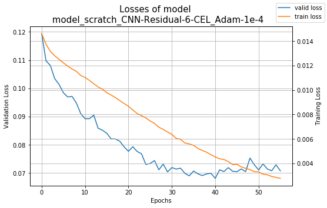

```python
tloss = np.loadtxt(f'{ConfigScratchModel.NAME}_train_loss.csv')
vloss = np.loadtxt(f'{ConfigScratchModel.NAME}_valid_loss.csv')
f, ax = plt.subplots(figsize=(8,5))
ax.plot(vloss,  label='valid loss')
ax.grid()
ax.set_xlabel("Epochs")
ax.set_ylabel('Validation Loss')
ax2=ax.twinx()
ax2.plot(tloss, 'C1', label='train loss')
ax2.grid()
ax2.set_xlabel("Epochs")
ax2.set_ylabel('Training Loss')
f.legend(loc="upper right")
plt.suptitle(f'Losses of model \n {ConfigScratchModel.NAME}', fontsize=15);
```

### Test the Model

Try out your model on the test dataset of dog images. Use the code cell below to calculate and print the test loss and accuracy. Ensure that your test accuracy is greater than 10%.

```python
def test(loaders, model, criterion, use_cuda):

    # monitor test loss and accuracy
    test_loss = 0.
    correct = 0.
    total = 0.

    model.eval()
    for batch_idx, (data, target) in enumerate(loaders['test']):
        # move to GPU
        if use_cuda:
            data, target = data.cuda(), target.cuda()
        # forward pass: compute predicted outputs by passing inputs to the model
        output = model(data)
        # calculate the loss
        loss = criterion(output, target)
        # update average test loss
        test_loss = test_loss + ((1 / (batch_idx + 1)) * (loss.data - test_loss))
        # convert output probabilities to predicted class
        pred = output.data.max(1, keepdim=True)[1]
        # compare predictions to true label
        correct += np.sum(np.squeeze(pred.eq(target.data.view_as(pred))).cpu().numpy())
        total += data.size(0)

    print('Test Loss: {:.6f}\n'.format(test_loss))

    print('\nTest Accuracy: %2d%% (%2d/%2d)' % (
        100. * correct / total, correct, total))
```

```python
# load state dict of the model
model_scratch.load_state_dict(torch.load(ConfigScratchModel.NAME + '.pt'))
# call test function
test(loaders_scratch, model_scratch, criterion_scratch, use_cuda)
```

```
Test Loss: 2.786911


Test Accuracy: 34% (285/836)
```

## Step 4: Create a CNN to Classify Dog Breeds (using Transfer Learning)

You will now use transfer learning to create a CNN that can identify dog breed from images. Your CNN must attain at least 60% accuracy on the test set.

### Specify Data Loaders for the Dog Dataset

I am going to **use the same data loaders from the previous step**, to be able to really compare the respective performances.

```python
# Specify data loaders
loaders_transfer = loaders_scratch.copy()
```

### (IMPLEMENTATION) Model Architecture

Use transfer learning to create a CNN to classify dog breed. Use the code cell below, and save your initialized model as the variable `model_transfer`.

```python
import torchvision.models as models
import torch.nn as nn

model_transfer = models.resnet.resnet152(pretrained=True)

if use_cuda:
    model_transfer = model_transfer.cuda()
```

```python
model_transfer
```

[output not shown]

[output cut: 427 more lines]

```
      (relu): ReLU(inplace=True)
    )
    (2): Bottleneck(
      (conv1): Conv2d(2048, 512, kernel_size=(1, 1), stride=(1, 1), bias=False)
      (bn1): BatchNorm2d(512, eps=1e-05, momentum=0.1, affine=True, track_running_stats=True)
      (conv2): Conv2d(512, 512, kernel_size=(3, 3), stride=(1, 1), padding=(1, 1), bias=False)
      (bn2): BatchNorm2d(512, eps=1e-05, momentum=0.1, affine=True, track_running_stats=True)
      (conv3): Conv2d(512, 2048, kernel_size=(1, 1), stride=(1, 1), bias=False)
      (bn3): BatchNorm2d(2048, eps=1e-05, momentum=0.1, affine=True, track_running_stats=True)
      (relu): ReLU(inplace=True)
    )
  )
  (avgpool): AdaptiveAvgPool2d(output_size=(1, 1))
  (fc): Linear(in_features=2048, out_features=1000, bias=True)
)
```

```python
# Freeze training for all "features" layers
for param in model_transfer.parameters():
    param.requires_grad = False

# Parameters of newly constructed modules have requires_grad=True by default
num_ftrs = model_transfer.fc.in_features
model_transfer.fc = nn.Linear(num_ftrs, 133)

if use_cuda:
    model_transfer = model_transfer.cuda()
```

**Question 5:** Outline the steps you took to get to your final CNN architecture and your reasoning at each step. Describe why you think the architecture is suitable for the current problem.

I had a look at the performances of the pretrained CNN on imagenet dataset (https://www.learnopencv.com/pytorch-for-beginners-image-classification-using-pre-trained-models/). It appears that the winners are ResNext, Inception and ResNet. On pytorch API, I could not load the 2 first, so chose the third.

I chose to adpot the pre trained Resnet152 to transfer its learning to my dog breed classification problem. Indeed, Resnet152 has seen and learn how to recognize image from imagenet dataset, that also contains dogs, so it should be ready to learn breed patterns now!

I kept all feature extraction pre-trained pattern, that I frozed, and only adapted and trained the last layer to output 133 objects (breeds).

### Specify Loss Function and Optimizer

Use the next code cell to specify a [loss function](http://pytorch.org/docs/master/nn.html#loss-functions) and [optimizer](http://pytorch.org/docs/master/optim.html). Save the chosen loss function as `criterion_transfer`, and the optimizer as `optimizer_transfer` below.

```python
criterion_transfer = nn.CrossEntropyLoss()
optimizer_transfer = optim.Adam(model_transfer.fc.parameters(), lr=0.001)
```

### Train and Validate the Model

Train and validate your model in the code cell below. [Save the final model parameters](http://pytorch.org/docs/master/notes/serialization.html) at filepath `'model_transfer.pt'`.

```python
# train the model
# model_transfer = train(n_epochs, loaders_transfer, model_transfer, optimizer_transfer, criterion_transfer, use_cuda, 'model_transfer.pt')
# load the model that got the best validation accuracy (uncomment the line below)
model_transfer.load_state_dict(torch.load('model_transfer.pt'))
```

```
<All keys matched successfully>
```

### Test the Model

Try out your model on the test dataset of dog images. Use the code cell below to calculate and print the test loss and accuracy. Ensure that your test accuracy is greater than 60%.

```python
test(loaders_transfer, model_transfer, criterion_transfer, use_cuda)
```

```
Test Loss: 0.591168


Test Accuracy: 81% (684/836)
```

### Predict Dog Breed with the Model

Write a function that takes an image path as input and returns the dog breed (`Affenpinscher`, `Afghan hound`, etc) that is predicted by your model.

```python
def infer_breed_transfer(model, img_path):
    """ Predicts the dog breed that is predicted by the model """
    # load the image and return the predicted breed
    prepare_image = transforms.Compose([transforms.RandomResizedCrop(224),
                                        transforms.ToTensor(),
                                        transforms.Normalize(mean=[0.485, 0.456, 0.406],
                                                            std=[0.229, 0.224, 0.225])])
    m = torch.nn.Softmax()
    img = Image.open(img_path).convert('RGB')
    img = prepare_image(img).unsqueeze(0)
    if use_cuda:
        img = img.cuda()
    model.eval()
    output = model.forward(img)  # Returns a Tensor of shape (batch, num class labels)
    probs = m(output) # Convert score in probabilities
    if use_cuda: #copy the tensor to host memory
        probs = probs.cpu()

    df = pd.DataFrame(data={'prob': probs.data.numpy().reshape(-1)*100, 'breed': dog_breeds})

    return df.sort_values(['prob'], ascending=False)

def predict_breed_transfer(img_path, model=None, verbose=False, infered=None):
    if infered is None:
        infered=infer_breed_transfer(model, img_path)
    prediction = infered.iloc[0]
    precision = prediction.prob  # Our prediction will be the index of the class label with the largest value.
    breed = prediction.breed  # Our prediction will be the index of the class label with the largest value.
    if verbose:
        print(f'Pretrained model predicted {breed} with precision %.2f %%.' % precision)  # Converts the index to a string using our labels dict
    return breed, precision # predicted class index
```

## Step 5: Write your Algorithm

Write an algorithm that accepts a file path to an image and first determines whether the image contains a human, dog, or neither. Then,

- if a **dog** is detected in the image, return the predicted breed.
- if a **human** is detected in the image, return the resembling dog breed.
- if **neither** is detected in the image, provide output that indicates an error.

You are welcome to write your own functions for detecting humans and dogs in images, but feel free to use the `face_detector` and `human_detector` functions developed above. You are **required** to use your CNN from Step 4 to predict dog breed.

Some sample output for our algorithm is provided below, but feel free to design your own user experience!

[figure not shown]

### Write your Algorithm

```python
import random
def run_app(img_path, full_report=False):
    # use face and dog detector (from part 1)
    is_human = face_detector(img_path)
    is_dog = dog_detector(img_path)

    infered = infer_breed_transfer(model_transfer, img_path)
    dog_breed, precision = predict_breed_transfer(img_path, infered=infered)

    max_prob = 100
    if is_human:
        max_prob = 50

    img = Image.open(img_path)
    if full_report:
        fig11 = plt.figure(figsize=(8, 3), constrained_layout=False)

        # gridspec inside gridspec
        plausible_breeeds = infered[:4]['breed'].values
        plausible_breeds_exemples = [glob(os.path.join(ConfigPath.dogs , 'train', plausible_breeed, '*.jpg'))[random.randint(0,20)] for plausible_breeed in plausible_breeeds]
        outer_grid = fig11.add_gridspec(1, 5, wspace=0.0, hspace=0.0)
        all_axes = fig11.get_axes()
        for ax in all_axes:
            for sp in ax.spines.values():
                sp.set_visible(False)
        fig11.add_subplot(outer_grid[0,0], xticks=[], yticks=[])
        show_image(img_path, resize=(224,224))
        for k, plausible_breeds_exemple in enumerate(plausible_breeds_exemples):
            fig11.add_subplot(outer_grid[0, k+1], xticks=[], yticks=[])
            show_image(plausible_breeds_exemple, resize=(224,224))
        plt.suptitle('What dog best suits you? ', fontsize=20)
        plt.figure()
        sns.barplot(data=infered[:4], x='prob', y='breed', orient='h')
        plt.xlim([0, max_prob])

    if is_human:
        print(f'Hi human, you look like {dog_breed} with precision %.2f %%.' % precision)
    elif is_dog:
        print(f'Hi dog, you look like {dog_breed} with precision %.2f %%.' % precision)
    else:
        print("Who are you?")
```

## Step 6: Test Your Algorithm

In this section, you will take your new algorithm for a spin! What kind of dog does the algorithm think that *you* look like? If you have a dog, does it predict your dog's breed accurately? If you have a cat, does it mistakenly think that your cat is a dog?

### Test Your Algorithm on Sample Images!

Test your algorithm at least six images on your computer. Feel free to use any images you like. Use at least two human and two dog images.

**Question 6:** Is the output better than you expected :) ? Or worse :( ? Provide at least three possible points of improvement for your algorithm.

**Answer:** (Three possible points for improvement)

My algorithm is pretty fun, but a bit disapointing, insofar as I don't see the simlilarities between the people and the sibling dog... When I have time, I'll try to:

- use open-cv to detect the human-face position in the image and do the testing on that part of the image only.
- train a Siamese network to recognize similarity between 2 pictures, and then compute a image-to-dog similarity matrice and output the dog breeds that has the more resembled pictures.
- run the dog-breed-network on all human database to see if a all dogs are equally represented across human, or not. If not, then understand why.
- looking inside the model to see how it behaves during training (see method here -> https://course.fast.ai/videos/?lesson=10), so that we can understand what part/feature on the human lead to the decision of dog-breed.
- run the test more than once and compute average and variance of each softmax probability before ploting the barchart.

```python
for file in np.hstack((human_files[:3], dog_files[:3])):
    run_app(file, full_report=False)
```

```
Hi human, you look like 093.Kerry_blue_terrier with precision 37.21 %.
Hi human, you look like 041.Bullmastiff with precision 37.70 %.
Hi human, you look like 056.Dachshund with precision 22.42 %.
Hi dog, you look like 016.Beagle with precision 74.75 %.
Hi dog, you look like 122.Pointer with precision 99.12 %.
Hi human, you look like 103.Mastiff with precision 76.20 %.
```

```
Hi human, you look like 016.Beagle with precision 54.11 %.
Hi human, you look like 042.Cairn_terrier with precision 10.11 %.
Hi human, you look like 017.Bearded_collie with precision 17.56 %.
```

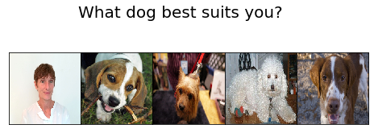

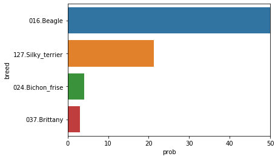

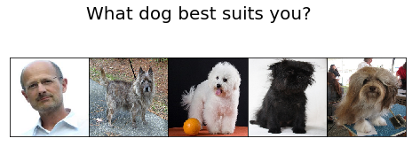

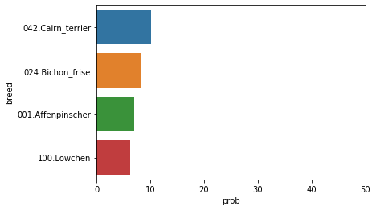

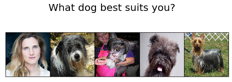

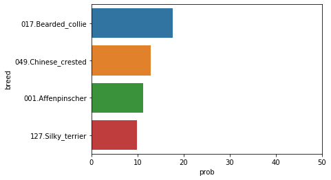

```python
for friend_file in glob('data/dog_people/*.jpg'):
    run_app(friend_file, full_report=True)
```

## Step 7: Compare scratch and transfert models

In this last step, we visualize the network performances, to see where the model is right or wrong. First, we show the confusion matrix for scratch and transfert model to evaluate specificity of the model.

Then we show in a barplot the misclassified pair of breeds and display the images of the first 5 misclassified pair of dogs.

```python
from sklearn.metrics import confusion_matrix
@torch.no_grad()
def get_all_preds(model, loader):
    all_preds = torch.tensor([])
    for batch in loader:
        images, labels = batch
        preds = model(images)
        all_preds = torch.cat(
            (all_preds, preds)
            ,dim=0
        )
    return all_preds

def get_confusion_matrix(image_folder, model_preds):
    return confusion_matrix(image_folder.targets, model_preds.argmax(dim=1))

def get_misclass_df(image_folder, model_preds, labels=dog_breeds):
    df = pd.DataFrame(np.vstack([image_folder.targets,
                                                   model_preds.argmax(dim=1)]).T,
                                    columns=['actual', 'prediction'])
    df = df.applymap(lambda k: labels[k].split('.')[-1])
    df['count'] = 1
    misclass_df = df[df['actual'] != df['prediction']].groupby(['actual', 'prediction']).sum().sort_values(['count'], ascending=False).reset_index()
    misclass_df['pair'] = misclass_df['actual'] + ' / ' + misclass_df['prediction']
    return misclass_df

def get_performance(model, image_folder, loader, labels=dog_breeds):
    preds = get_all_preds(model, loader)
    cm = get_confusion_matrix(image_folder, preds)
    misclass_df = get_misclass_df(image_folder, preds, labels)
    worst_misclass_df = misclass_df[['pair', 'count']].take(range(30))
    return cm, misclass_df, worst_misclass_df
```

```python
SET = image_folders['test']
LOADER = loaders_scratch['test']

scratch_cm, scratch_misclass_df, scratch_worst_misclass_df = get_performance(model_scratch, SET, LOADER)
transfer_cm, transfer_misclass_df, transfer_worst_misclass_df = get_performance(model_transfer, SET, LOADER)
```

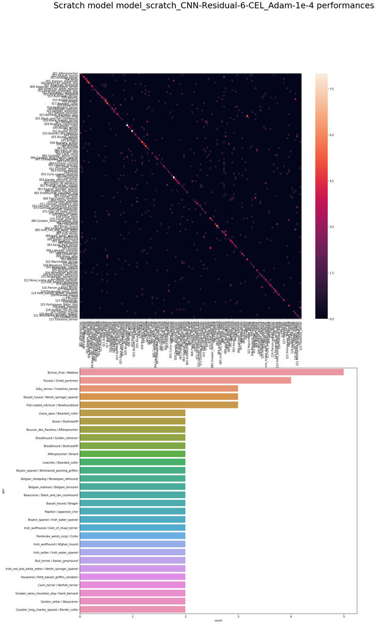

```python
fig, ax = plt.subplots(2, 1 , figsize=(18, 36))
_ = sns.heatmap(scratch_cm, ax=ax[0], yticklabels=dog_breeds, xticklabels=dog_breeds, robust=False)
sns.barplot(data=scratch_worst_misclass_df, y='pair', x='count', orient='h', ax=ax[1]);
plt.suptitle(f'Scratch model {ConfigScratchModel.NAME} performances', fontsize=30);
```

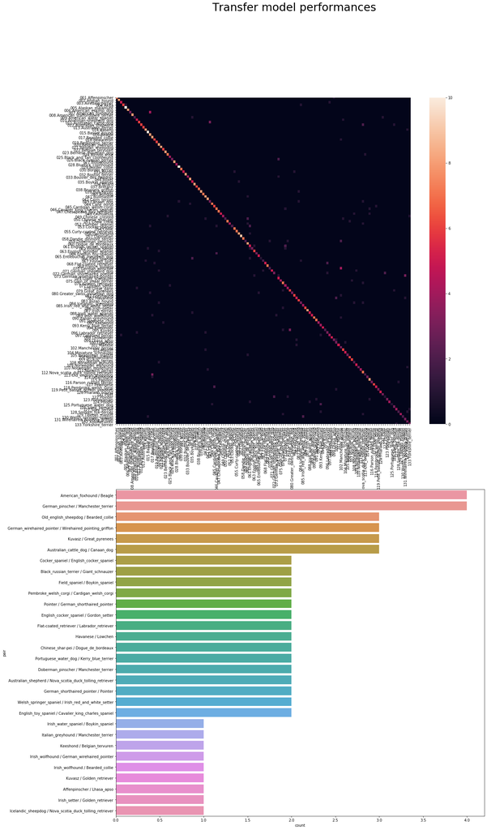

```python
fig, ax = plt.subplots(2, 1 , figsize=(18, 36))
_ = sns.heatmap(transfer_cm, ax=ax[0], yticklabels=dog_breeds, xticklabels=dog_breeds, robust=False)
sns.barplot(data=transfer_worst_misclass_df, y='pair', x='count', orient='h', ax=ax[1]);
plt.suptitle('Transfer model performances', fontsize=30);
```

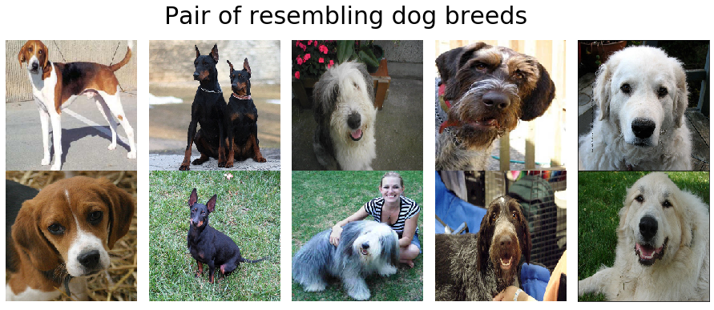

```python
fig11 = plt.figure(figsize=(16,6), constrained_layout=False)
outer_grid = fig11.add_gridspec(2, 5, wspace=0.0, hspace=0.0)
for k_row, row in transfer_worst_misclass_df[:5].iterrows():
    breed1, breed2= row.pair.split('/')
    breed1_example = glob(os.path.join(ConfigPath.dogs , 'train', '*' + breed1.strip() , '*.jpg'))[random.randint(0,20)]
    breed2_example = glob(os.path.join(ConfigPath.dogs , 'train', '*' + breed2.strip() , '*.jpg'))[random.randint(0,20)]
    all_axes = fig11.get_axes()
    for ax in all_axes:
        for sp in ax.spines.values():
            sp.set_visible(False)
    fig11.add_subplot(outer_grid[0,k_row], xticks=[], yticks=[])
    show_image(breed1_example, resize=(224,224))
    fig11.add_subplot(outer_grid[1,k_row], xticks=[], yticks=[])
    show_image(breed2_example, resize=(224,224))
plt.suptitle('Pair of resembling dog breeds', fontsize=30);
```

When I look at where my model fails, I can't really be angry with him, as I myself would have trouble distinguishing between a American Foxhood and Beagle, or between a Kuvasz and a Great Pyrenees...

| American Foxhood | Beagle |
| --- | --- |